# Estudios de Informática, Multimedia y Telecomunicaciones

# Estado de salud en Europa

Análisis con perspectiva de género

Autora: Jesica Piñón Rodríguez

Junio 2021

**Introducción**

En este documento se presenta el código utilizado y los pasos seguidos para la obtención de los resultados presentados en la memoria del trabajo final de máster. Dicho trabajo realiza un análisis del estado de salud en Europa. El análisis pone especial atención a los indicadores de esperanza de vida y años de vida saludables, lesiones por accidentes, absentismo laboral y salud mental. Los indicadores se analizan poniendo especial interés en las diferencias entre hombres y mujeres para entender el sesgo de género existente en Europa.

Los datos del estudio se obtienen del conjunto de datos de **Health status** de [Eurostat](https://ec.europa.eu/eurostat/web/health/data/database%22)

# 1 Recolección de los datos

El primer paso es instalar los paquetes y cargar las librerías necesarias:

```r
is.installed <- function(mypkg) is.element(mypkg, installed.packages()[,1])
if (!is.installed("ggplot2")){install.packages("ggplot2",repos="http://cran.r-project.org")}
if (!is.installed("data.table")){install.packages("data.table",repos="http://cran.r-project.org")}
if (!is.installed("rmarkdown")){install.packages("rmarkdown",repos="http://cran.r-project.org")}
if (!is.installed("dplyr")){install.packages("dplyr",repos="http://cran.r-project.org")}
if (!is.installed("forcats")){install.packages("forcats",repos="http://cran.r-project.org")}
if (!is.installed("viridis")){install.packages("viridis",repos="http://cran.r-project.org")}
if (!is.installed("treemapify")){install.packages("treemapify",repos="http://cran.r-project.org")}
if (!is.installed("splitstackshape")){install.packages("splitstackshape",repos="http://cran.r-project.org")}
if (!is.installed("kableExtra")){install.packages("kableExtra",repos="http://cran.r-project.org")}
if (!is.installed("hrbrthemes")){install.packages("hrbrthemes",repos="http://cran.r-project.org")}
if (!is.installed("factoextra")){install.packages("factoextra",repos="http://cran.r-project.org")}
if (!is.installed("corrplot")){install.packages("corrplot",repos="http://cran.r-project.org")}
if (!is.installed("directlabels")){install.packages("directlabels",repos="http://cran.r-project.org")}
if (!is.installed("gridExtra")){install.packages("gridExtra",repos="http://cran.r-project.org")}
if (!is.installed("ggalt")){install.packages("ggalt",repos="http://cran.r-project.org")}

suppressPackageStartupMessages(library(ggplot2))
suppressPackageStartupMessages(library(data.table))
suppressPackageStartupMessages(library(rmarkdown))
suppressPackageStartupMessages(library(dplyr))
suppressPackageStartupMessages(library(forcats))
suppressPackageStartupMessages(library(viridis))
suppressPackageStartupMessages(library(treemapify))
suppressPackageStartupMessages(library(splitstackshape))
suppressPackageStartupMessages(library(kableExtra))
suppressPackageStartupMessages(library(hrbrthemes))
suppressPackageStartupMessages(library(factoextra))
suppressPackageStartupMessages(library(corrplot))
suppressPackageStartupMessages(library(directlabels))
suppressPackageStartupMessages(library(gridExtra))
suppressPackageStartupMessages(library(ggalt))


print ("Librerías cargadas\n")
```

```
## [1] "Librerías cargadas\n"
```

```r
outplotdir <- 'D:/UOC_MASTER/TFM/Salud/PAC4/plots/'
srcdir <- 'D:/UOC_MASTER/TFM/Salud/PAC4/src/HealthStatus/data/'
```

```r
##Cargamos funciones
source("D:/UOC_MASTER/TFM/Salud/PAC4/src/violin_plot.R")
source("D:/UOC_MASTER/TFM/Salud/PAC4/src/timeseries_plot.R")
source("D:/UOC_MASTER/TFM/Salud/PAC4/src/hist_plot.R")
source("D:/UOC_MASTER/TFM/Salud/PAC4/src/treemap_plot.R")
```

Ejecuto script general de procesamiento de datos

```r
#source("D:/UOC_MASTER/TFM/Salud/PAC4/src/01.R", local = knitr::knit_global())
```

**Años de vida saludables**

```r
srcdir <- 'D:/UOC_MASTER/TFM/Salud/PAC4/src/HealthStatus/data/'
hly <- readRDS(paste0(srcdir,"hly_ts.rds"))
#summary(hly)
options(knitr.kable.NA = '')
#Presentación resumen datos
kable(summary(hly),digits=2, align='l', caption="Tabla resumen de los datos relativos a los años de vida saludables") %>%
  kable_styling(bootstrap_options = "striped", full_width = F)
```

Tabla resumen de los datos relativos a los años de vida saludables

|  | geo | unit | sex | indic_he | variable | value | Category | Indicator | pais |
| --- | --- | --- | --- | --- | --- | --- | --- | --- | --- |
|  | Length:21804 | PC: 5508 | F:7734 | Length:21804 | 2019 : 1194 | Min. : 2.70 | Healthy_life_years:21804 | hlth_hlye :14256 | Length:21804 |
|  | Class :character | YR:16296 | M:7734 | Class :character | 2018 : 1194 | 1st Qu.:18.40 |  | hlth_hlye_h : 2700 | Class :character |
|  | Mode :character |  | T:6336 | Mode :character | 2017 : 1194 | Median :35.40 |  | hlth_silc_17: 4848 | Mode :character |
|  |  |  |  |  | 2016 : 1194 | Mean :43.58 |  |  |  |
|  |  |  |  |  | 2015 : 1194 | 3rd Qu.:70.30 |  |  |  |
|  |  |  |  |  | 2014 : 1194 | Max. :96.50 |  |  |  |
|  |  |  |  |  | (Other):14640 | NA’s :1531 |  |  |  |

```r
unique(hly$indic_he)
```

```
##  [1] "HLY_PC_0"  "HLY_PC_50" "HLY_PC_65" "HLY_0"     "HLY_50"
##  [6] "HLY_65"    "LE_0"      "LE_50"     "LE_65"     "HE_50"
## [11] "HE_65"     "HE_BIRTH"
```

**Absentismo laboral debido a problemas de salud**

```r
absw <- readRDS(paste0(srcdir,"absw.rds"))
#summary(absw)
kable(summary(absw),digits=2, align='l', caption="Tabla resumen de los datos relativos al absentismo laboral debido a problemas de salud") %>%
  kable_styling(bootstrap_options = "striped", full_width = F)
```

Tabla resumen de los datos relativos al absentismo laboral debido a problemas de salud

|  | variable | lev_limit | sex | age | unit | time | value | Category | Indicator | isced11 | deg_urb | pais |
| --- | --- | --- | --- | --- | --- | --- | --- | --- | --- | --- | --- | --- |
|  | Length:16632 | MOD : 1386 | F:5544 | TOTAL :1188 | PC:16632 | Min. :2014 | Min. : 0.00 | Absence_from_work_due_to_health_problems:16632 | hlth_ehis_aw1d:5544 | ED0-2: 1386 | DEG1 : 1386 | Length:16632 |
|  | Class :character | NONE : 1386 | M:5544 | Y_GE65 :1188 |  | 1st Qu.:2014 | 1st Qu.:19.80 |  | hlth_ehis_aw1e:5544 | ED3_4: 1386 | DEG2 : 1386 | Class :character |
|  | Mode :character | SEV : 1386 | T:5544 | Y_GE75 :1188 |  | Median :2014 | Median :31.60 |  | hlth_ehis_aw1u:5544 | ED5-8: 1386 | DEG3 : 1386 | Mode :character |
|  |  | SM_SEV: 1386 |  | Y15-24 :1188 |  | Mean :2014 | Mean :33.38 |  |  | TOTAL: 1386 | TOTAL: 1386 |  |
|  |  | NA’s :11088 |  | Y15-29 :1188 |  | 3rd Qu.:2014 | 3rd Qu.:46.70 |  |  | NA’s :11088 | NA’s :11088 |  |
|  |  |  |  | Y15-44 :1188 |  | Max. :2014 | Max. :92.70 |  |  |  |  |  |
|  |  |  |  | (Other):9504 |  |  | NA’s :5604 |  |  |  |  |  |

**Lesiones por accidentes**

```r
ifa <- readRDS(paste0(srcdir,"ifa.rds"))
#summary(ifa)
#unit PC_S -->  Standardised percentage
kable(summary(ifa),digits=2, align='l', caption="Tabla resumen de los datos relativos a las lesiones por accidentes") %>%
  kable_styling(bootstrap_options = "striped", full_width = F)
```

Tabla resumen de los datos relativos a las lesiones por accidentes

|  | variable | unit | accident | isced11 | sex | age | time | value | Category | Indicator | deg_urb | hlthcare | pais |
| --- | --- | --- | --- | --- | --- | --- | --- | --- | --- | --- | --- | --- | --- |
|  | Length:80784 | PC :80784 | HOM :13464 | ED0-2:13464 | F:26928 | TOTAL : 4752 | Min. :2014 | Min. : 0.00 | Injuries_from_accidents:80784 | hlth_ehis_ac1e:26928 | DEG1 : 6732 | HC : 6732 | Length:80784 |
|  | Class :character | PC_S: 0 | HOM_LEIS:13464 | ED3_4:13464 | M:26928 | Y_GE65 : 4752 | 1st Qu.:2014 | 1st Qu.: 1.70 |  | hlth_ehis_ac1u:26928 | DEG2 : 6732 | HC_AMB : 6732 | Class :character |
|  | Mode :character |  | LEIS :13464 | ED5-8:13464 | T:26928 | Y_GE75 : 4752 | Median :2014 | Median : 3.90 |  | hlth_ehis_ac2e:26928 | DEG3 : 6732 | HC_HOSP: 6732 | Mode :character |
|  |  |  | RD_TRF :13464 | TOTAL:13464 |  | Y15-19 : 4752 | Mean :2014 | Mean :10.99 |  |  | TOTAL: 6732 | NHC : 6732 |  |
|  |  |  | NA’s :26928 | NA’s :26928 |  | Y15-24 : 4752 | 3rd Qu.:2014 | 3rd Qu.:10.20 |  |  | NA’s :53856 | NA’s :53856 |  |
|  |  |  |  |  |  | Y15-29 : 4752 | Max. :2014 | Max. :96.10 |  |  |  |  |  |
|  |  |  |  |  |  | (Other):52272 |  | NA’s :18771 |  |  |  |  |  |

**Salud y bienestar autopercibidos**

```r
sph <-readRDS(paste0(srcdir,"sph.rds"))
kable(summary(sph),digits=2, align='l', caption="Tabla resumen de los datos relativos a la salud y bienestar autopercibidos") %>%
  kable_styling(bootstrap_options = "striped", full_width = F)
```

Tabla resumen de los datos relativos a la salud y bienestar autopercibidos

|  | variable | hlth_pb | sex | age | c_birth | unit | time | value | Category | Indicator | citizen | isced11 | quantile | deg_urb | lev_perc | levels | lev_limit | wstatus | geo | pais |
| --- | --- | --- | --- | --- | --- | --- | --- | --- | --- | --- | --- | --- | --- | --- | --- | --- | --- | --- | --- | --- |
|  | Length:8898594 | DPR : 38688 | F:2966198 | Y_GE65 : 497298 | EU28_FOR : 233334 | PC :8878938 | Min. :2014 | Min. : 0 | Self-perceived_healt_and_well_being:8898594 | hlth_silc_10:1764000 | EU28_FOR : 238761 | ED0-2: 229497 | QU1 : 309066 | DEG1 : 270216 | B_VB : 462306 | B_VB : 743106 | MOD : 8316 | EMP : 205842 | AT : 203448 | Length:8898594 |
|  | Class :character | DPR_MJR: 38688 | M:2966198 | Y_GE75 : 497298 | FOR : 233334 | PC_POP: 19656 | 1st Qu.:2014 | 1st Qu.: 3 |  | hlth_silc_24:1641276 | FOR : 238761 | ED3_4: 229497 | QU2 : 309066 | DEG2 : 270216 | BAD : 462306 | BAD : 743106 | NONE : 8316 | INAC_OTH: 205842 | BE : 203448 | Class :character |
|  | Mode :character | DPR_OTH: 38688 | T:2966198 | Y25-34 : 497298 | NAT : 233334 |  | Median :2014 | Median : 14 |  | hlth_silc_23:1594866 | NAT : 238761 | ED5-8: 229497 | QU3 : 309066 | DEG3 : 270216 | FAIR : 462306 | FAIR : 743106 | SEV : 8316 | POP : 205842 | BG : 203448 | Mode :character |
|  |  | NA’s :8782530 |  | Y35-44 : 497298 | NEU28_FOR : 233334 |  | Mean :2014 | Mean : 25 |  | hlth_silc_01:1592682 | NEU28_FOR : 238761 | TOTAL: 231171 | QU4 : 309066 | TOTAL: 270216 | GOOD : 462306 | GOOD : 743106 | SM_SEV: 8316 | RET : 205842 | CH : 203448 |  |
|  |  |  |  | Y45-54 : 497298 | EU27_2020_FOR: 199563 |  | 3rd Qu.:2014 | 3rd Qu.: 41 |  | hlth_silc_18:1020600 | EU27_2020_FOR: 211302 | NA’s :7978932 | QU5 : 309066 | NA’s :7817730 | VBAD : 462306 | VBAD : 743106 | NA’s :8865330 | UNE : 205842 | CY : 203448 |  |
|  |  |  |  | Y45-64 : 497298 | (Other) : 553371 |  | Max. :2014 | Max. :100 |  | hlth_silc_02: 824460 | (Other) : 565110 |  | TOTAL: 309066 |  | (Other):1101516 | (Other):1653954 |  | (Other) : 563472 | (Other):7420644 |  |
|  |  |  |  | (Other):5914806 | NA’s :7212324 |  | NA’s :8437884 | NA’s :3662582 |  | (Other) : 460710 | NA’s :7167138 |  | NA’s :7044198 |  | NA’s :5485548 | NA’s :3529110 |  | NA’s :7305912 | NA’s : 460710 |  |

# 2 Análisis exploratorio de los datos

## 2.1 Años de vida saludables y esperanza de vida

```r
srcdir <- 'D:/UOC_MASTER/TFM/Salud/PAC4/src/HealthStatus/data/'
hly <- readRDS(paste0(srcdir,"hly_ts.rds"))
```

**violin plots**

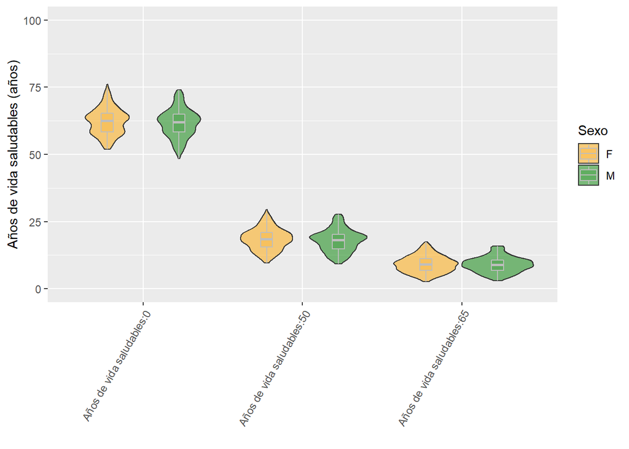

```r
p <- violin_plot(hly,"HLY","Años de vida saludables",0,100,'YR') # no es interesante
p
```

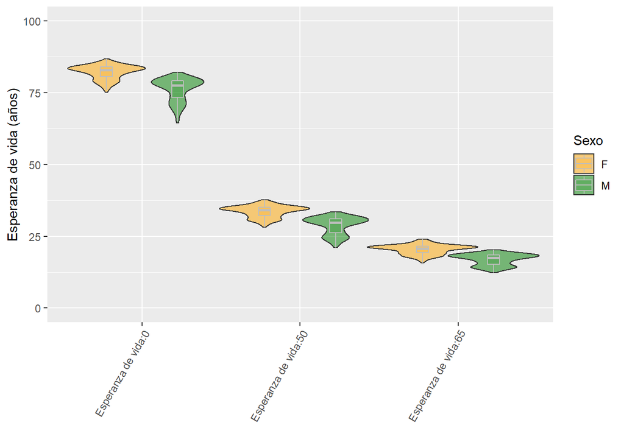

```r
#dev.off()
#ggsave(paste0(outplotdir,"AÑOSVIDASALUDABLE_2004_2019.png"),plot = p, dpi = 300)

p <- violin_plot(hly,"LE","Esperanza de vida",0,100,'YR')
p
```

```r
#dev.off()
#ggsave(paste0(outplotdir,"ESPERANZAVIDA_2004_2019.png"),plot = p, dpi = 300)
```

```r
summary(hly[sex=='F' & indic_he=='LE_0' & !is.na(pais) & as.character(variable) >= 2004]$value)
```

```
##    Min. 1st Qu.  Median    Mean 3rd Qu.    Max.    NA's
##   75.10   80.70   82.90   82.22   84.00   86.70       4
```

```r
summary(hly[sex=='M' & indic_he=='LE_0' & !is.na(pais) & as.character(variable) >= 2004]$value)
```

```
##    Min. 1st Qu.  Median    Mean 3rd Qu.    Max.    NA's
##   64.50   73.38   77.60   76.22   79.20   82.10       4
```

```r
summary(hly[sex=='F' & indic_he=='LE_65' & !is.na(pais) & as.character(variable) >= 2004]$value)
```

```
##    Min. 1st Qu.  Median    Mean 3rd Qu.    Max.    NA's
##   15.70   19.20   20.80   20.43   21.60   24.00       4
```

```r
summary(hly[sex=='M' & indic_he=='LE_65' & !is.na(pais) & as.character(variable) >= 2004]$value)
```

```
##    Min. 1st Qu.  Median    Mean 3rd Qu.    Max.    NA's
##   12.30   15.20   17.50   16.89   18.50   20.30       4
```

**Series temporales**

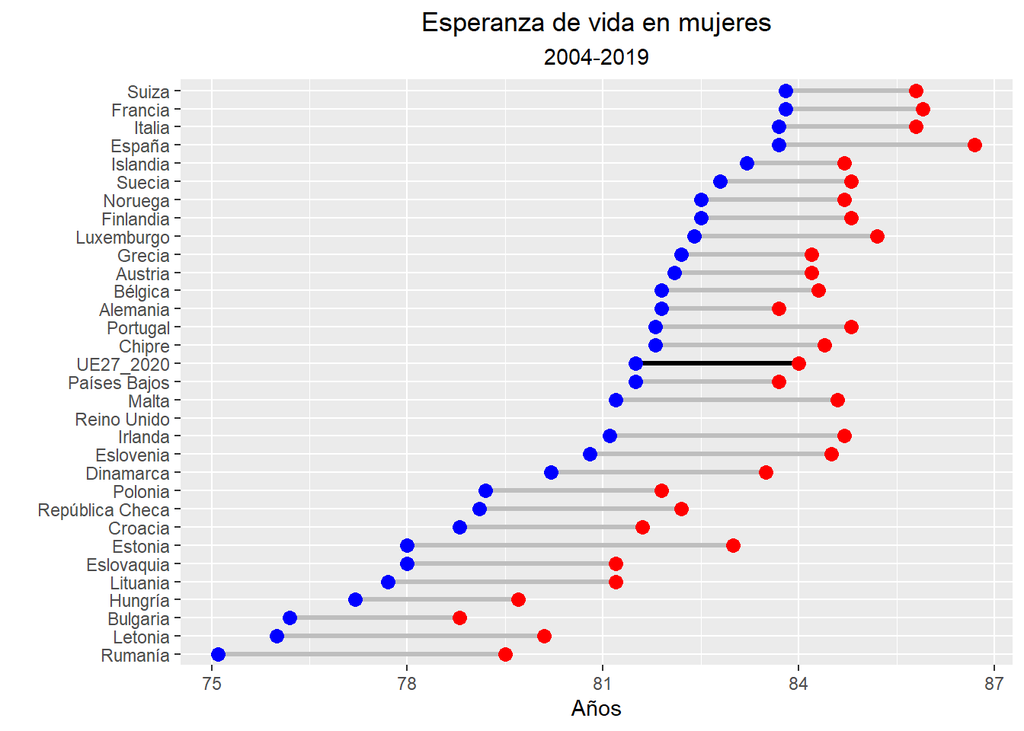

```r
#2004-2019
p <- ts_change(hly,'LE_0','Esperanza de vida',2004,2019,'YR','F')
p
```

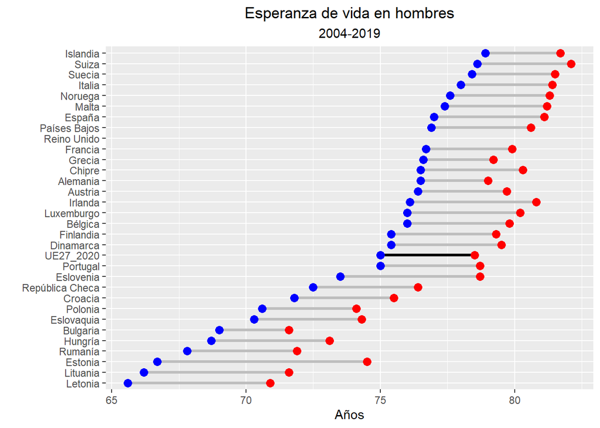

```r
#dev.off()
#ggsave(paste0(outplotdir,"TS_esperanzavida_2004_2019_F.png"),plot = p, dpi = 300)
p <- ts_change(hly,'LE_0','Esperanza de vida',2004,2019,'YR','M')
p
```

```r
#dev.off()
#ggsave(paste0(outplotdir,"TS_esperanzavida_2004_2019_M.png"),plot = p, dpi = 300)
```

**AÑOS DE VIDA SALUDABLES Y LA PERCEPCION**

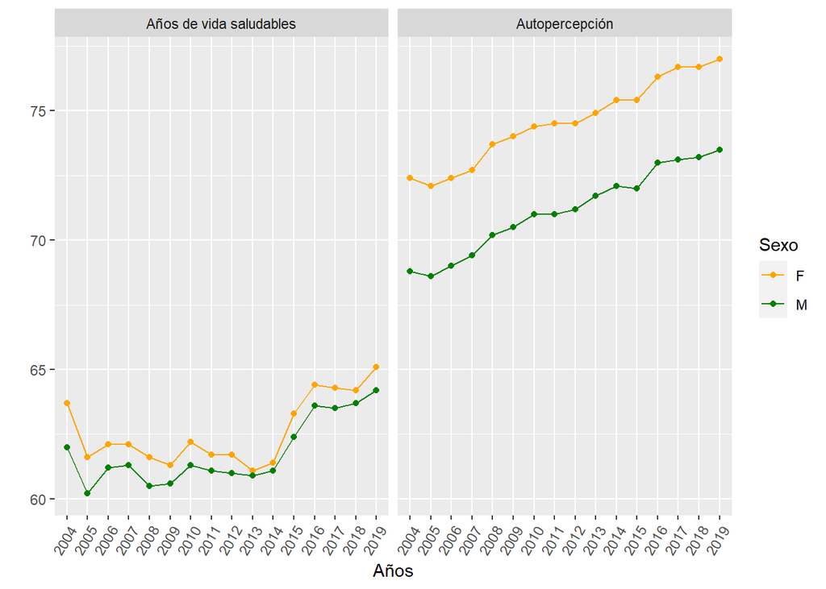

```r
temp <- hly[unit=='YR' & Indicator != 'hlth_hlye_h' & sex !='T']
temp <- temp[!grep('LE',indic_he)]
temp <- temp[geo=='EU27_2020']
#Añadiendo etiquetas
temp[grep('_0|BIRTH',indic_he),label:='Nacimiento']
temp[grep('_50',indic_he),label:='A los 50']
temp[grep('_65',indic_he),label:='A los 65']
temp[Indicator=='hlth_hlye',Indicator_name:='Años de vida saludables']
temp[Indicator=='hlth_silc_17',Indicator_name:='Autopercepción']
# Para poder ordenar las etiquetas
temp$ind = factor(temp$label, levels=c(unique(temp$label)))
#Plot
temp2 <- temp[ind=='Nacimiento']
p <- ggplot(temp2,aes(x=as.character(variable),y=value,color=sex,group=sex))+geom_point()+facet_wrap(~Indicator_name)+geom_line()+ylab('')+xlab('Años')+theme(axis.text.x = element_text(angle = 60, hjust=1))+scale_color_manual(name = "Sexo",values = c("#FFA500", "#008000"))
p
```

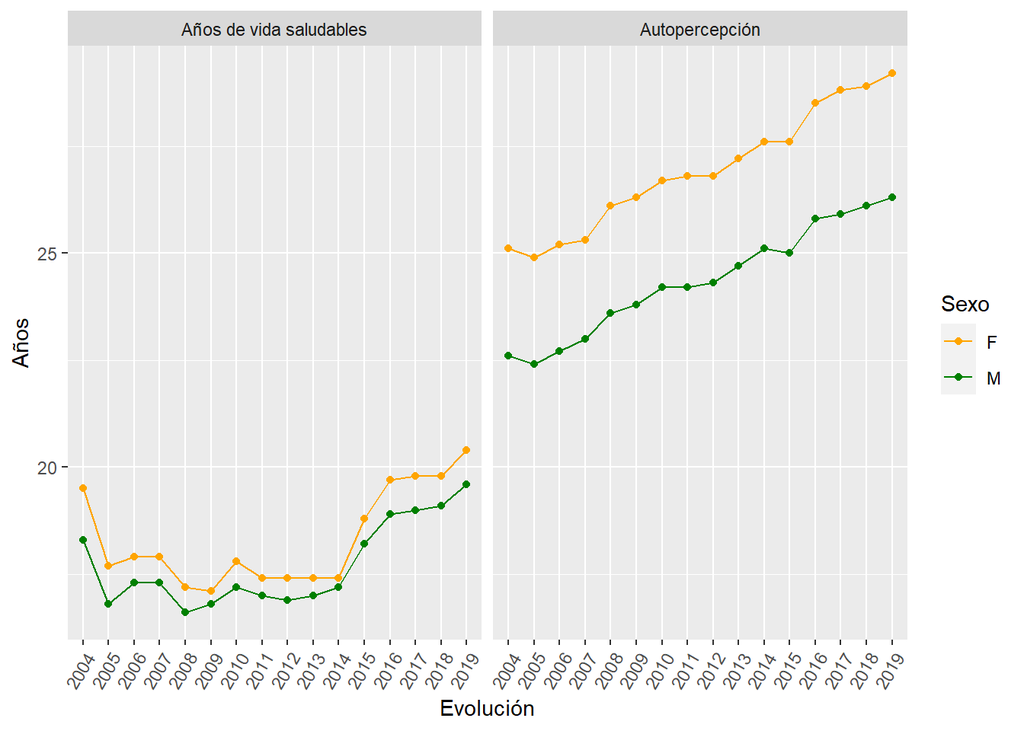

```r
#dev.off()
#ggsave(paste0(outplotdir,"Evolucion_AñosSaludablesVSAutopercepcion_Nacimiento.png"),plot = p, dpi = 300)
temp2 <- temp[ind=='A los 50']
p <- ggplot(temp2,aes(x=as.character(variable),y=value,color=sex,group=sex))+geom_point()+facet_wrap(~Indicator_name)+geom_line()+ylab('Años')+xlab('Evolución')+theme(axis.text.x = element_text(angle = 60, hjust=1))+scale_color_manual(name = "Sexo",values = c("#FFA500", "#008000"))
p
```

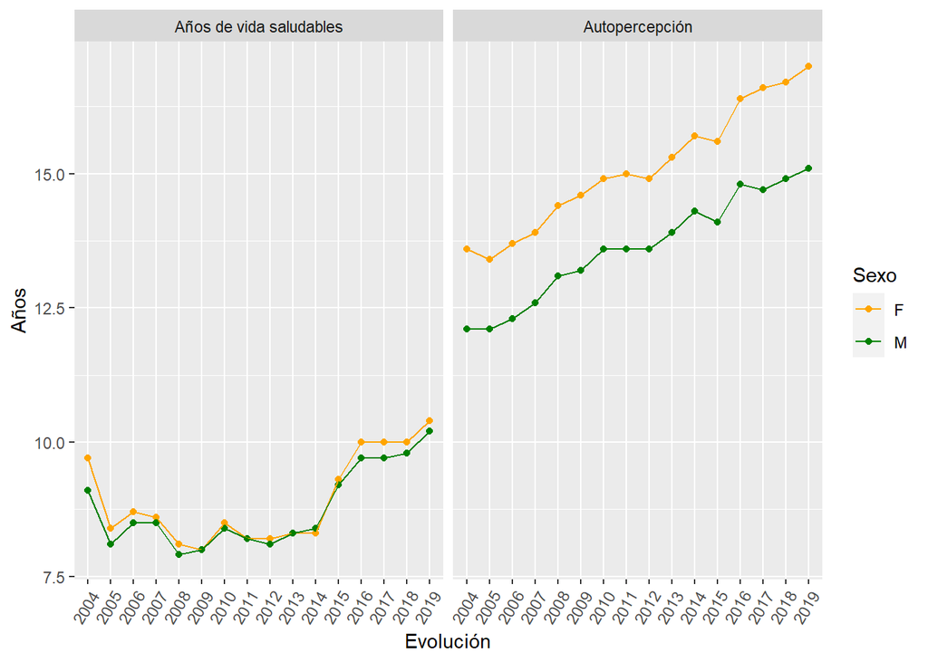

```r
#dev.off()
#ggsave(paste0(outplotdir,"Evolucion_AñosSaludablesVSAutopercepcion_50.png"),plot = p, dpi = 300)
temp2 <- temp[ind=='A los 65']
p <- ggplot(temp2,aes(x=as.character(variable),y=value,color=sex,group=sex))+geom_point()+facet_wrap(~Indicator_name)+geom_line()+ylab('Años')+xlab('Evolución')+theme(axis.text.x = element_text(angle = 60, hjust=1))+scale_color_manual(name = "Sexo",values = c("#FFA500", "#008000"))
p
```

```r
#dev.off()
#ggsave(paste0(outplotdir,"Evolucion_AñosSaludablesVSAutopercepcion_65.png"),plot = p, dpi = 300)

#Por año
#for (year in unique(temp$variable)){
year <- '2019'
  print(year)
```

```
## [1] "2019"
```

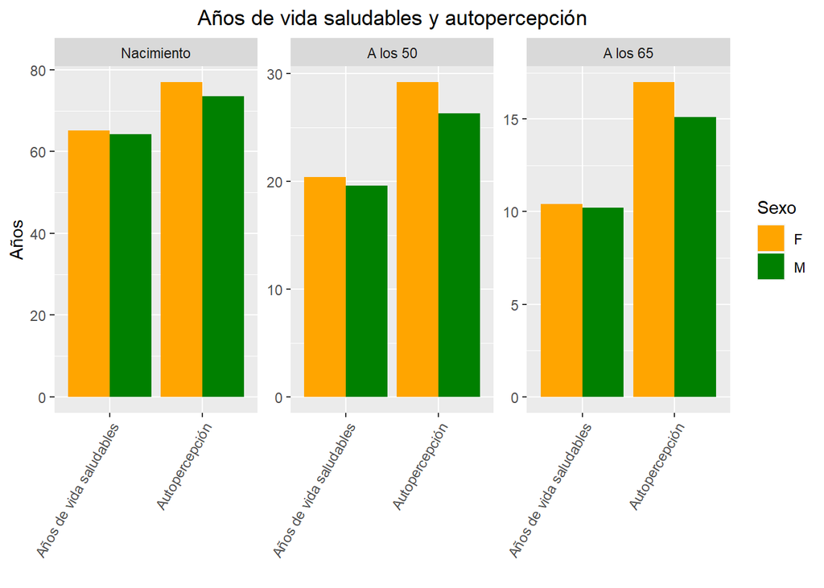

```r
p <- ggplot(data = temp[variable==year], aes(x=factor(Indicator_name), y=value,fill=sex)) + facet_wrap(~ind, scales="free_y")+geom_bar(stat='identity',position=position_dodge()) +ggtitle('Años de vida saludables y autopercepción')+theme(axis.text.x = element_text(angle = 60, hjust=1))+labs(y='Años',x='')+theme(plot.title = element_text(hjust = 0.5))+scale_fill_manual(name = "Sexo",values = c("#FFA500", "#008000"))
p
```

```r
#dev.off()
#ggsave(paste0(outplotdir,"AñosSaludables_",year,".png"),plot = p, dpi = 300)
#}
```

**Ratio esperanza de vida y años de vida saludables por país**

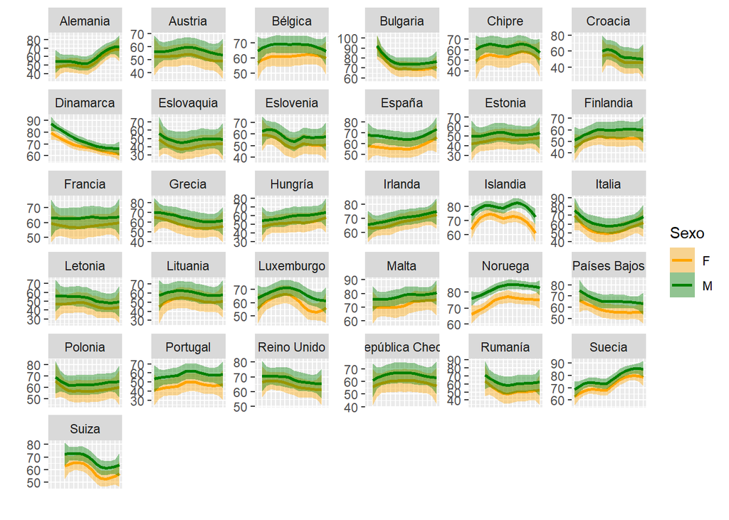

```r
temp <- hly[unit=='PC' & Indicator=='hlth_hlye' & sex !='T']
temp <- temp[!is.na(pais)] #por país
#Añadiendo etiquetas
temp[grep('_0|BIRTH',indic_he),label:='Nacimiento']
temp[grep('_50',indic_he),label:='A los 50']
temp[grep('_65',indic_he),label:='A los 65']
# Para poder ordenar las etiquetas
temp$ind = factor(temp$label, levels=c(unique(temp$label)))

p <- ggplot(data = temp, aes(x=as.character(variable),y=value,fill=sex,group=sex,color=sex))+facet_wrap(~pais, scales="free_y") +xlab('')+ylab('')+geom_smooth(aes(group=sex))+scale_color_manual(name = "Sexo",values = c("#FFA500", "#008000"))+scale_fill_manual(name = "Sexo",values = c("#FFA500", "#008000"))+theme(
  axis.text.x = element_blank(),
  axis.ticks.x = element_blank()
)
p
```

```r
#ggsave(p,filename=paste0(outplotdir,"ComparativaPaisesPCAñosSaludables.png"),width = 10, height = 8)
```

## 2.2 Lesiones por accidentes

```r
ifa <- readRDS(paste0(srcdir,"ifa.rds"))
ifa$time <- NULL
```

```r
# por sexo y accidente (edad total y nivel total) y toda europa
p <- treemap_plot(ifa,'hlth_ehis_ac1e','TOTAL','accident','all')
```

```
## [1] "Análisis por sexo"
```

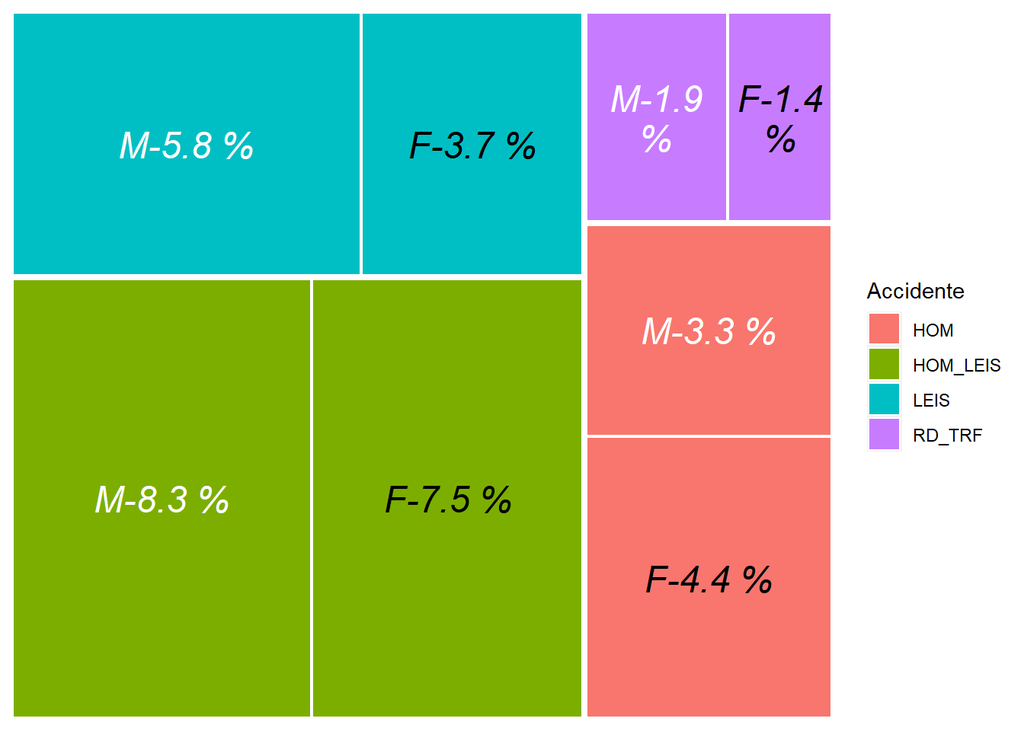

```r
p
```

```r
#ggsave(p,filename=paste0(outplotdir,"Tiposaccidentes.png"),width = 10, height = 10)
```

Al unir con la gravedad de las lesiones, no se observan patrones diferentes

```r
# por sexo y asistencia médica (edad total y nivel total) y toda europa
p <- treemap_plot(ifa,'hlth_ehis_ac2e','TOTAL','hlthcare','all')
```

```
## [1] "Análisis por sexo"
```

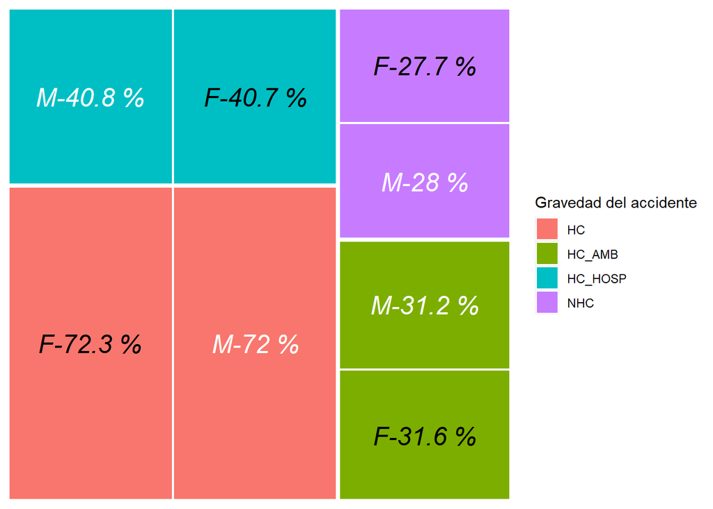

```r
p
```

```r
#ggsave(p,filename=paste0(outplotdir,"AsistenciaMedica.png"),width = 10, height = 10)
```

```r
temp <- ifa[Indicator=='hlth_ehis_ac1e']
temp <- temp[age !='TOTAL']

for (cat in unique(temp$accident)){
  print(cat)
  if (cat=='HOM'){cat2 <- 'domésticos'}
  if (cat=='HOM_LEIS'){cat2 <- 'domésticos y ocio'}
  if (cat=='LEIS'){cat2 <- 'de ocio'}
  if (cat=='RD_TRF'){cat2 <- 'de tráfico'}
temp2 <- temp[accident==cat & sex!='T' & isced11=='TOTAL' & variable=='EU27_2020']
#pruebo categorias edad
temp2 <- temp2[age == 'Y15-19' | age=='Y20-24' | age=='Y25-34' | age=='Y35-44' | age=='Y45-54' | age=='Y55-64' | age=='Y_GE65' | age=='Y_GE75']
#Orden específico
temp2$age <- factor(temp2$age, levels=c("Y15-19", "Y20-24", "Y25-34","Y35-44","Y45-54","Y55-64","Y_GE65","Y_GE75"))
temp2[,freq:=round((value/sum(value))*100,1),by=age]
p <- ggplot(temp2,
       aes(x = age,
           y = freq,
           fill = sex)) + geom_bar(stat = "identity")+scale_fill_manual(name = "Sexo",values = c("#FFA500", "#008000"))+xlab("Grupos de edad")+ ylab("")+
theme(axis.text.x=element_text(hjust=1,angle=60,size=20),plot.title = element_text(hjust = 0.5,size=25),axis.title.x = element_text(size=20),legend.text = element_text(size=15),legend.title = element_text(size=15))+
geom_text(aes(label=paste0(freq," %")),position=position_stack(vjust = 0.5),size=5,fontface = "bold")+ggtitle(paste0("Accidentes ",cat2))
p
#ggsave(p,filename=paste0(outplotdir,"Accidentes_",cat2,".png"),width = 10, height = 10)
}
```

```
## [1] "HOM"
## [1] "HOM_LEIS"
## [1] "LEIS"
## [1] "RD_TRF"
```

**Análisis por nivel educativo y grado de urbanización**

```r
##por accidetne segun sexo y nivel educativo
p <- treemap_plot(ifa,'hlth_ehis_ac1e','isced11','accident','F')
```

```
## [1] "Análisis por nivel educativo"
```

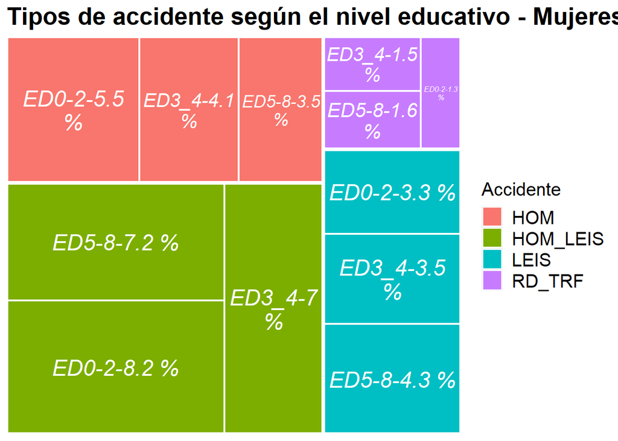

```r
p <- p + ggtitle('Tipos de accidente según el nivel educativo - Mujeres') +theme(plot.title = element_text(size = 20, face = "bold"),legend.text = element_text(size=15),legend.title = element_text(size=15))
p
```

```r
#ggsave(p,filename=paste0(outplotdir,"Accidentes_niveleducativo_mujeres.png"),width = 12, height = 10)

p <- treemap_plot(ifa,'hlth_ehis_ac1e','isced11','accident','M')
```

```
## [1] "Análisis por nivel educativo"
```

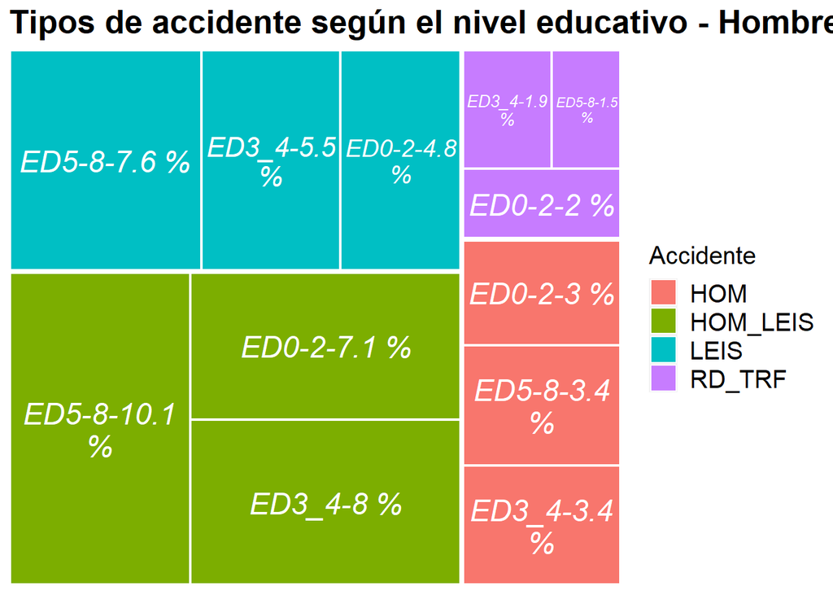

```r
p <- p + ggtitle('Tipos de accidente según el nivel educativo - Hombres') +theme(plot.title = element_text(size = 20, face = "bold"),legend.text = element_text(size=15),legend.title = element_text(size=15))
p
```

```r
#ggsave(p,filename=paste0(outplotdir,"Accidentes_niveleducativo_hombres.png"),width = 12, height = 10)


# accidente segun sexo y grado urbanismo
p <- treemap_plot(ifa,'hlth_ehis_ac1u','deg_urb','accident','F')
```

```
## [1] "Análisis por grado urbanismo"
```

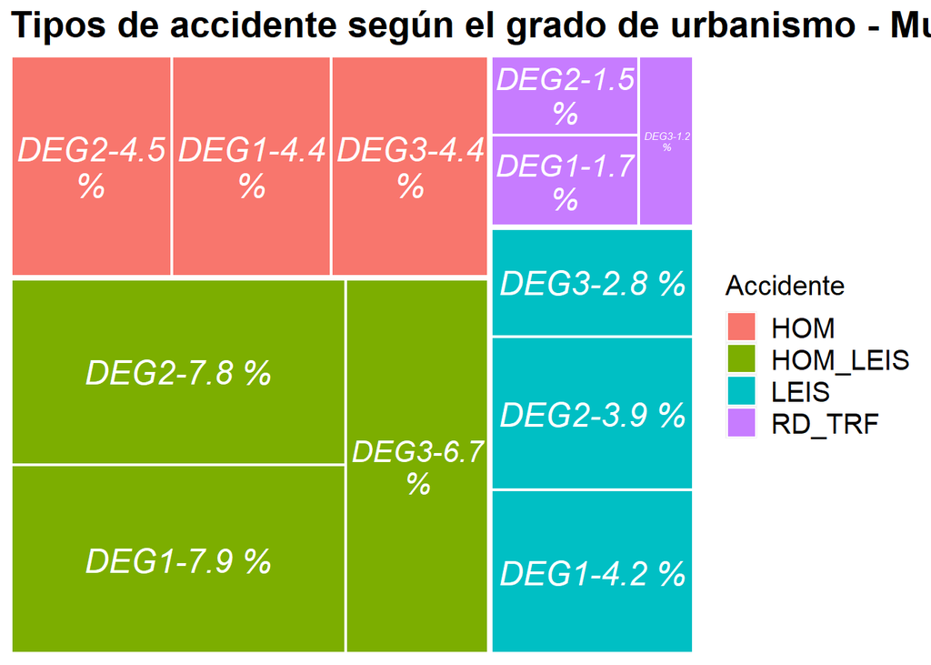

```r
p <- p + ggtitle('Tipos de accidente según el grado de urbanismo - Mujeres') +theme(plot.title = element_text(size = 20, face = "bold"),legend.text = element_text(size=15),legend.title = element_text(size=15))
p
```

```r
#ggsave(p,filename=paste0(outplotdir,"Accidentes_urbanismo_mujeres.png"),width = 12, height = 10)
p <- treemap_plot(ifa,'hlth_ehis_ac1u','deg_urb','accident','M')
```

```
## [1] "Análisis por grado urbanismo"
```

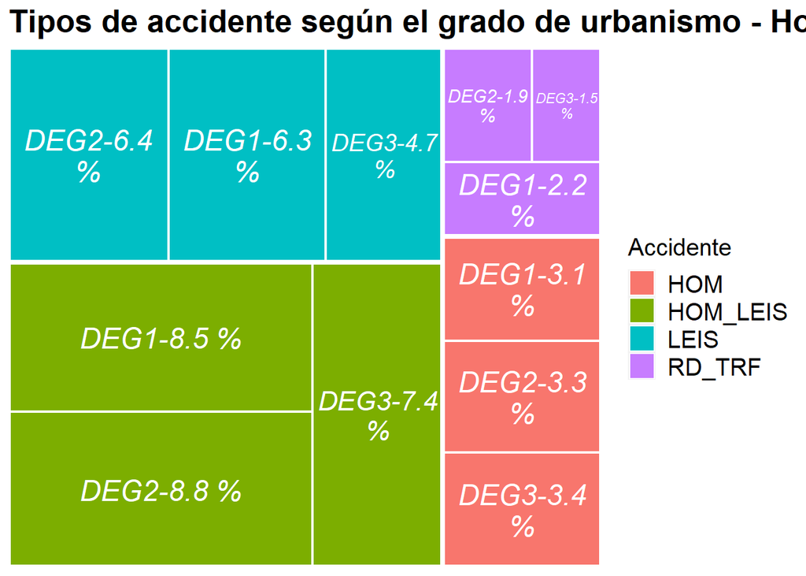

```r
p <- p + ggtitle('Tipos de accidente según el grado de urbanismo - Hombres') +theme(plot.title = element_text(size = 20, face = "bold"),legend.text = element_text(size=15),legend.title = element_text(size=15))
p
```

```r
#ggsave(p,filename=paste0(outplotdir,"Accidentes_urbanismo_hombres.png"),width = 12, height = 10)
```

**Análisis por países, sexo y categoría de accidente**

```r
temp <- ifa[Indicator=='hlth_ehis_ac1e']
for (cat in unique(temp$accident)){
   if (cat=='HOM'){cat2 <- 'domésticos'}
  if (cat=='HOM_LEIS'){cat2 <- 'domésticos y ocio'}
  if (cat=='LEIS'){cat2 <- 'de ocio'}
  if (cat=='RD_TRF'){cat2 <- 'de tráfico'}
temp2 <- temp[accident==cat & sex!='T']
#todas las edades y niveles
temp2 <- temp2[isced11 == 'TOTAL'  & age=='TOTAL']

p <- ggplot(temp2[!is.na(pais)],
       aes(x = pais,
           y = value,
           fill = sex)) +
  geom_bar(stat = "identity",
           position = position_dodge())+theme(axis.text.x = element_text(angle = 60, hjust=1,size=15))+ggtitle(paste0('Proporción de accidentes ',cat2,' por países'))+theme(plot.title = element_text(hjust = 0.5))+xlab('')+ylab('')+labs(fill='Sexo')+scale_fill_manual(name = "Sexo",values = c("#FFA500", "#008000"))+theme(plot.title = element_text(size = 20, face = "bold"),legend.text = element_text(size=15),legend.title = element_text(size=15),axis.text.y = element_text(size=15))
# añadir línea de media europea
p <- p + geom_hline(yintercept=temp2[variable=='EU27_2020' & sex=='M']$value,linetype="dashed", color = '#008000')
p <- p + geom_hline(yintercept=temp2[variable=='EU27_2020' & sex=='F']$value,linetype="dashed", color = '#FFA500')
#ggsave(p,filename=paste0(outplotdir,"Accidentes_PAISES_",cat,".png"),width = 10, height = 10)

}
```

## 2.3 Absentismo laboral

```r
absw <- readRDS(paste0(srcdir,"absw.rds"))
absw$time <- NULL
# Según nivel educativo
p <- treemap_plot(absw,'hlth_ehis_aw1e','isced11','isced11','all')
```

```
## [1] "Análisis por nivel educativo y sexo"
```

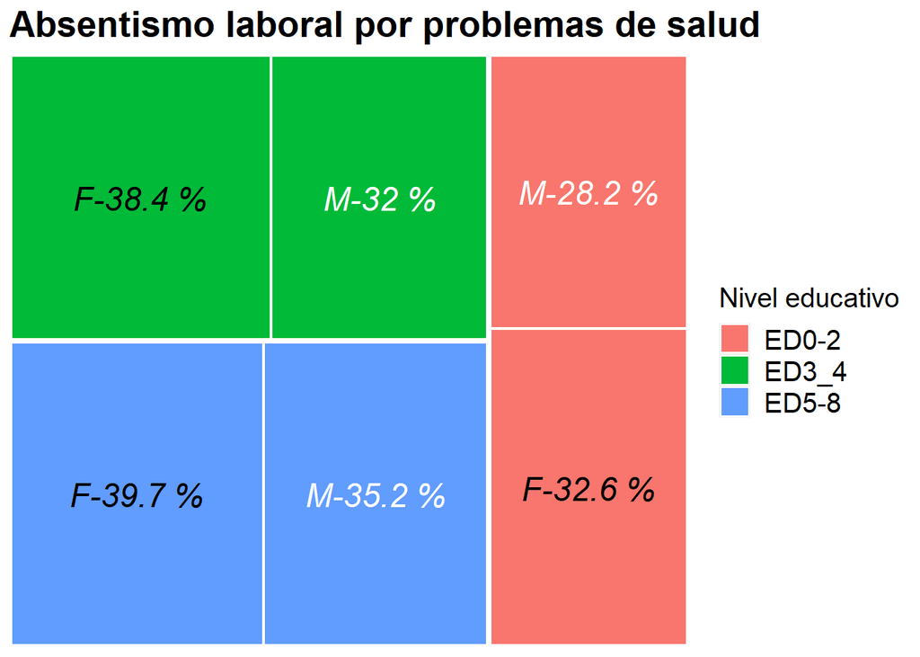

```r
p <- p + ggtitle('Absentismo laboral por problemas de salud') +theme(plot.title = element_text(size = 20, face = "bold"),legend.text = element_text(size=15),legend.title = element_text(size=15))
p
```

```r
#ggsave(p,filename=paste0(outplotdir,"Absentismo_niveleducativo.png"),width = 12, height = 10)

# Según grado urbanismo
p <- treemap_plot(absw,'hlth_ehis_aw1u','deg_urb','deg_urb','all')
```

```
## [1] "Análisis por grado urbanismo y sexo"
```

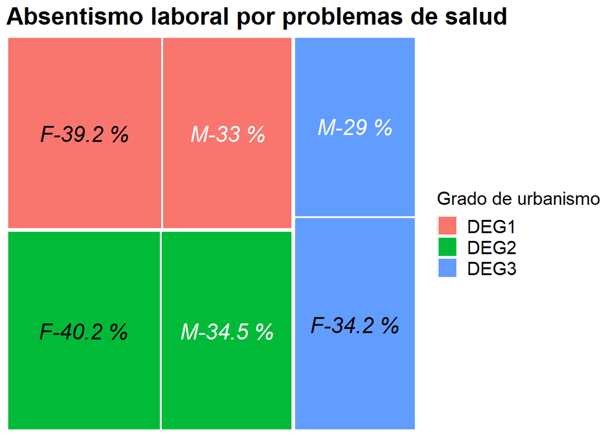

```r
p <- p + ggtitle('Absentismo laboral por problemas de salud') +theme(plot.title = element_text(size = 20, face = "bold"),legend.text = element_text(size=15),legend.title = element_text(size=15))
p
```

```r
#ggsave(p,filename=paste0(outplotdir,"Absentismo_urbanismo.png"),width = 12, height = 10)
```

**Análisis ausencia por países y sexo**

```r
temp <- absw[Indicator=='hlth_ehis_aw1e']
temp2 <- temp[sex!='T']
#todas las edades y niveles
temp2 <- temp2[isced11 == 'TOTAL'  & age=='TOTAL']
p <- ggplot(temp2[!is.na(pais)],
       aes(x = pais,
           y = value,
           fill = sex)) +
  geom_bar(stat = "identity",
           position = position_dodge())+theme(axis.text.x = element_text(angle = 60, hjust=1,size=15))+ggtitle('Proporción de absentismo laboral por países')+theme(plot.title = element_text(hjust = 0.5))+xlab('')+ylab('')+labs(fill='Sexo')+scale_fill_manual(name = "Sexo",values = c("#FFA500", "#008000"))+theme(plot.title = element_text(size = 20, face = "bold"),legend.text = element_text(size=15),legend.title = element_text(size=15),axis.text.y = element_text(size=15))
# añadir línea de media europea
p <- p + geom_hline(yintercept=temp2[variable=='EU27_2020' & sex=='M']$value,linetype="dashed", color = '#008000')
p <- p + geom_hline(yintercept=temp2[variable=='EU27_2020' & sex=='F']$value,linetype="dashed", color = '#FFA500')
#ggsave(p,filename=paste0(outplotdir,"Absentismo_PAISES_",cat,".png"),width = 10, height = 10)
```

**Nivel de limitación**

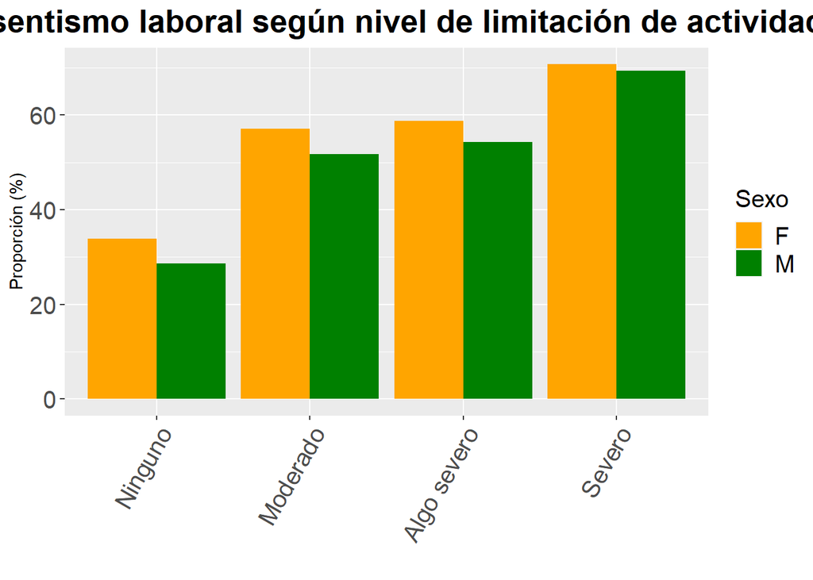

```r
temp <- absw[Indicator=='hlth_ehis_aw1d']
temp <- temp[variable=='EU27_2020' & sex!='T']

#PARA TODAS LAS EDADES
temp2 <- temp[age=='TOTAL']
temp2[lev_limit=='NONE',label:='Ninguno']
temp2[lev_limit=='NONE',id:='a']
temp2[lev_limit=='MOD',id:='b']
temp2[lev_limit=='SM_SEV',id:='c']
temp2[lev_limit=='SEV',id:='d']
temp2[lev_limit=='MOD',label:='Moderado']
temp2[lev_limit=='SEV',label:='Severo']
temp2[lev_limit=='SM_SEV',label:='Algo severo']
#Orden específico
temp2$label <- factor(temp2$label, levels=c("Ninguno", "Moderado", "Algo severo","Severo"))
p <- ggplot(data = temp2, aes(x=label, y=value,fill=sex))+geom_bar(stat='identity',position=position_dodge())+ggtitle('Limitaciones')+theme(plot.title = element_text(hjust = 0.5))+xlab('')+ylab('Proporción (%)')+scale_fill_manual(name = "Sexo",values = c("#FFA500", "#008000"))+theme(axis.text.x = element_text(angle = 60, hjust=1,size=15))+ggtitle('Absentismo laboral según nivel de limitación de actividad') +theme(plot.title = element_text(size = 20, face = "bold"),legend.text = element_text(size=15),legend.title = element_text(size=15),axis.text.y = element_text(size=15),axis.title.x=element_text(size=15))
p
```

```r
#ggsave(p,filename=paste0(outplotdir,"Abssentismo_Limitaciones.png"),width = 10, height = 10)
```

## 2.4 Salud mental

```r
sph <-readRDS(paste0(srcdir,"sph.rds"))
sph <- sph[unit=='PC']
#Etiquetas
sph[hlth_pb=='DPR',label:='Síntomas depresivos']
sph[hlth_pb=='DPR_MJR',label:='Síntomas depresivos severos']
sph[hlth_pb=='DPR_OTH',label:='Otros síntomas depresivos']

mh1 <- sph[grep('mh1',Indicator)] #current depressive symptons
mh2 <- sph[grep('mh2',Indicator)] # severity of current depressive symptons
silc <- sph[grep('silc',Indicator)] # self-perceived health
```

**Problemas de salud según nivel educativo y sexo**

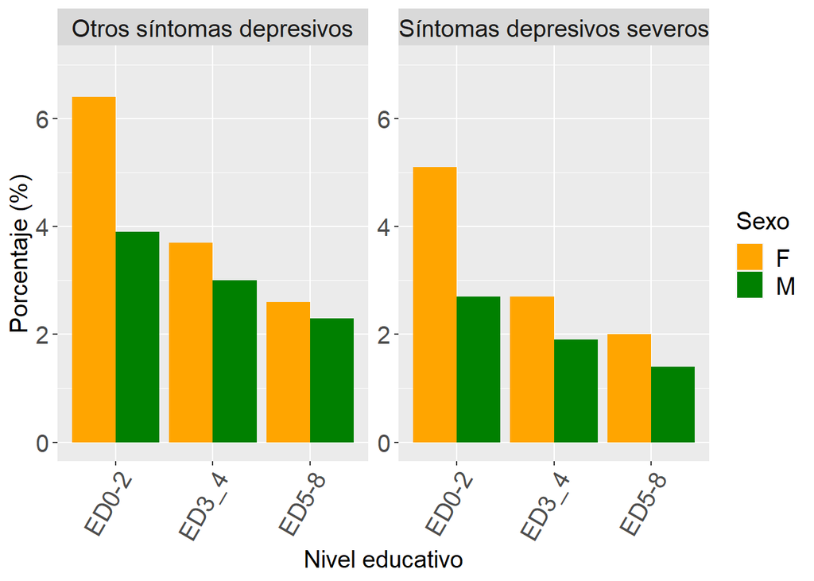

```r
mh1_subset <- mh1[age=='TOTAL' & sex !='T']
mh2_subset <- mh2[age=='TOTAL' & sex !='T']
#nivel educativo
temp <- mh1_subset[Indicator=='hlth_ehis_mh1e' & isced11!='TOTAL']
temp2 <- temp[variable=='EU27_2020']
temp2 <- temp2[hlth_pb != 'DPR']
p <- ggplot(data = temp2, aes(x=factor(isced11), y=value,fill=sex)) + facet_wrap(~label, scales="free_y")+geom_bar(stat='identity',position=position_dodge()) +xlab('Nivel educativo')+ylab('Porcentaje (%)')+theme(axis.text.x = element_text(angle = 60, hjust=1,size=15),legend.text = element_text(size=15),legend.title = element_text(size=15),axis.title.x=element_text(size=15),axis.title.y=element_text(size=15),axis.text.y=element_text(size=15))+scale_fill_manual(name = "Sexo",values = c("#FFA500", "#008000"))+scale_y_continuous(limits = c(0,round(max(temp2$value)+1,0)))+ theme(strip.text = element_text(size=15))
p
```

```r
#ggsave(p,filename=paste0(outplotdir,"SALUDMENTAL_NIVELEDUCATIVO.png"),width = 10, height = 10)
```

**grado urbanismo**

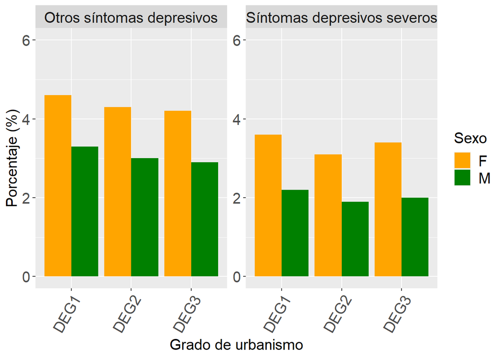

```r
temp <- mh1_subset[Indicator=='hlth_ehis_mh1u' & deg_urb!='TOTAL']
temp2 <- temp[variable=='EU27_2020']
temp2 <- temp2[hlth_pb != 'DPR']
p <- ggplot(data = temp2, aes(x=factor(deg_urb), y=value,fill=sex)) + facet_wrap(~label, scales="free_y")+geom_bar(stat='identity',position=position_dodge()) +xlab('Grado de urbanismo')+ylab('Porcentaje (%)')+theme(axis.text.x = element_text(angle = 60, hjust=1,size=15),legend.text = element_text(size=15),legend.title = element_text(size=15),axis.title.x=element_text(size=15),axis.title.y=element_text(size=15),axis.text.y=element_text(size=15))+scale_fill_manual(name = "Sexo",values = c("#FFA500", "#008000"))+scale_y_continuous(limits = c(0,round(max(temp2$value)+1,0)))+ theme(strip.text = element_text(size=15))
p
```

```r
#ggsave(p,filename=paste0(outplotdir,"SALUDMENTAL_GRADOURBANISMO.png"),width = 10, height = 10)
```

**Nivel de ingresos**

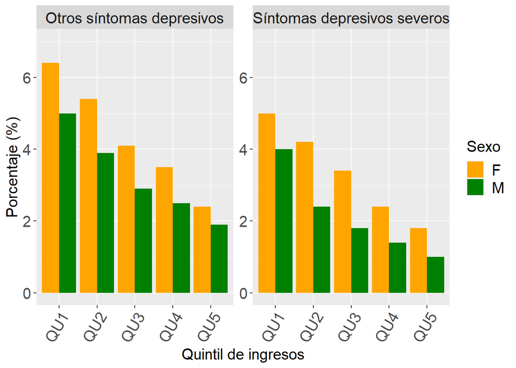

```r
#nivel de ingresos
temp <- mh1_subset[Indicator=='hlth_ehis_mh1i' & quantile !='TOTAL']
temp2 <- temp[variable=='EU27_2020']
temp2 <- temp2[hlth_pb != 'DPR']
p <- ggplot(data = temp2, aes(x=factor(quantile), y=value,fill=sex)) + facet_wrap(~label, scales="free_y")+geom_bar(stat='identity',position=position_dodge()) +xlab('Quintil de ingresos')+ylab('Porcentaje (%)')+theme(axis.text.x = element_text(angle = 60, hjust=1,size=15),legend.text = element_text(size=15),legend.title = element_text(size=15),axis.title.x=element_text(size=15),axis.title.y=element_text(size=15),axis.text.y=element_text(size=15))+scale_fill_manual(name = "Sexo",values = c("#FFA500", "#008000"))+scale_y_continuous(limits = c(0,round(max(temp2$value)+1,0)))+ theme(strip.text = element_text(size=15))
p
```

```r
#ggsave(p,filename=paste0(outplotdir,"SALUDMENTAL_INGRESOS.png"),width = 10, height = 10)
```

**Severity of current depressive symptoms**

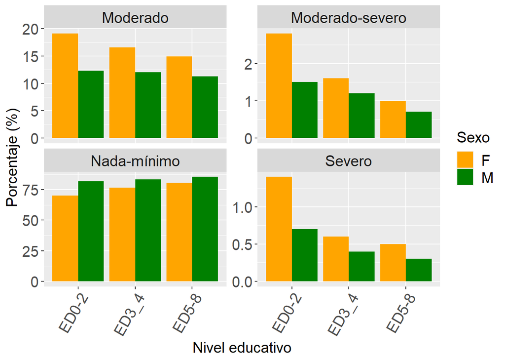

```r
#percepcion propia
mh2_subset[levels=='MOD',label:='Moderado']
mh2_subset[levels=='NONE_MIN',label:='Nada-mínimo']
mh2_subset[levels=='MILD',label:='Moderado']
#mh2_subset[levels=='D_MODS_SEV',label:='Moderate']
mh2_subset[levels=='MODS',label:='Moderado-severo']
mh2_subset[levels=='SEV',label:='Severo']
mh2_subset <- mh2_subset[!is.na(label)]
temp <- mh2_subset[Indicator=='hlth_ehis_mh2e' & isced11!='TOTAL']
temp2 <- temp[variable=='EU27_2020']

p <- ggplot(data = temp2, aes(x=factor(isced11), y=value,fill=sex)) + facet_wrap(~label, scales="free_y")+geom_bar(stat='identity',position=position_dodge()) +xlab('Nivel educativo')+ylab('Porcentaje (%)')+theme(axis.text.x = element_text(angle = 60, hjust=1,size=15),legend.text = element_text(size=15),legend.title = element_text(size=15),axis.title.x=element_text(size=15),axis.title.y=element_text(size=15),axis.text.y=element_text(size=15))+scale_fill_manual(name = "Sexo",values = c("#FFA500", "#008000"))+ theme(strip.text = element_text(size=15))
p
```

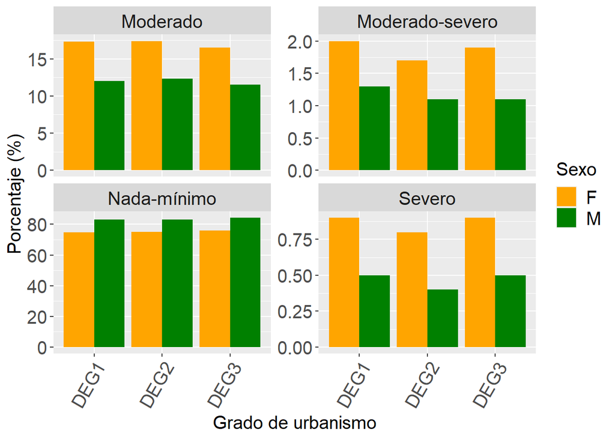

```r
#ggsave(p,filename=paste0(outplotdir,"SALUDMENTAL_SEVERIDAD_EDUCATIVO.png"),width = 10, height = 10)

#urbanismo
temp <- mh2_subset[Indicator=='hlth_ehis_mh2u' & deg_urb!='TOTAL']
temp2 <- temp[variable=='EU27_2020']

p <- ggplot(data = temp2, aes(x=factor(deg_urb), y=value,fill=sex)) + facet_wrap(~label, scales="free_y")+geom_bar(stat='identity',position=position_dodge()) +xlab('Grado de urbanismo')+ylab('Porcentaje (%)')+theme(axis.text.x = element_text(angle = 60, hjust=1,size=15),legend.text = element_text(size=15),legend.title = element_text(size=15),axis.title.x=element_text(size=15),axis.title.y=element_text(size=15),axis.text.y=element_text(size=15))+scale_fill_manual(name = "Sexo",values = c("#FFA500", "#008000"))+ theme(strip.text = element_text(size=15))
p
```

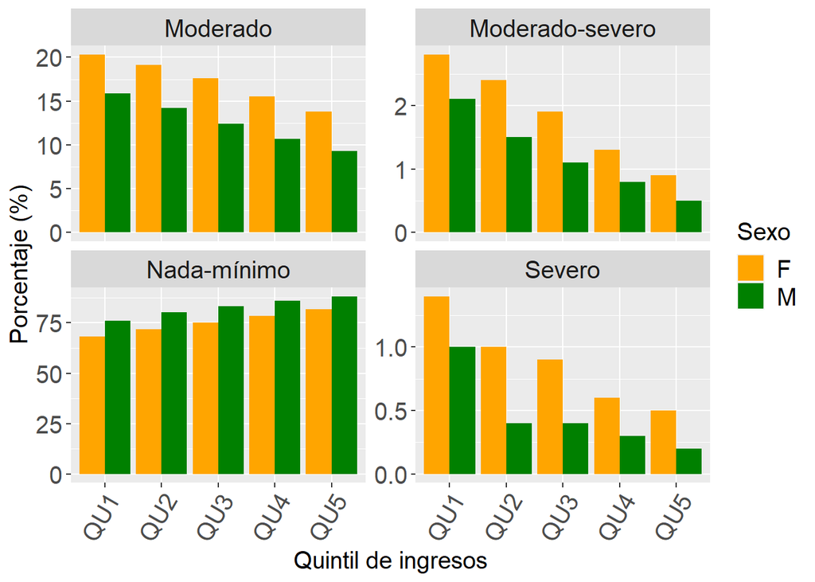

```r
#ggsave(p,filename=paste0(outplotdir,"SALUDMENTAL_SEVERIDAD_URBANISMO.png"),width = 10, height = 10)

#nivel ingresos
temp <- mh2_subset[Indicator=='hlth_ehis_mh2i' & quantile!='TOTAL']
temp2 <- temp[variable=='EU27_2020']

p <- ggplot(data = temp2, aes(x=factor(quantile), y=value,fill=sex)) + facet_wrap(~label, scales="free_y")+geom_bar(stat='identity',position=position_dodge()) +xlab('Quintil de ingresos')+ylab('Porcentaje (%)')+theme(axis.text.x = element_text(angle = 60, hjust=1,size=15),legend.text = element_text(size=15),legend.title = element_text(size=15),axis.title.x=element_text(size=15),axis.title.y=element_text(size=15),axis.text.y=element_text(size=15))+scale_fill_manual(name = "Sexo",values = c("#FFA500", "#008000"))+ theme(strip.text = element_text(size=15))
p
```

```r
#ggsave(p,filename=paste0(outplotdir,"SALUDMENTAL_SEVERIDAD_INGRESOS.png"),width = 10, height = 10)
```

**Por países**

```r
temp <- sph[Indicator=='hlth_ehis_mh1b']
temp2 <- temp[sex!='T']
#todas las edades - síntomas depresión de todo tipo
temp2 <- temp2[age=='TOTAL' & hlth_pb =='DPR']
p <- ggplot(temp2[!is.na(pais)],
       aes(x = pais,
           y = value,
           fill = sex)) +
  geom_bar(stat = "identity",
           position = position_dodge())+theme(axis.text.x = element_text(angle = 60, hjust=1,size=15))+ggtitle('Proporción de síntomas depresivos por países')+theme(plot.title = element_text(hjust = 0.5))+xlab('')+ylab('')+labs(fill='Sexo')+scale_fill_manual(name = "Sexo",values = c("#FFA500", "#008000"))+theme(plot.title = element_text(size = 20, face = "bold"),legend.text = element_text(size=15),legend.title = element_text(size=15),axis.text.y = element_text(size=15))
# añadir línea de media europea
p <- p + geom_hline(yintercept=temp2[variable=='EU27_2020' & sex=='M' & c_birth=='NAT']$value,linetype="dashed", color = '#008000')
p <- p + geom_hline(yintercept=temp2[variable=='EU27_2020' & sex=='F' & c_birth=='NAT']$value,linetype="dashed", color = '#FFA500')
#ggsave(p,filename=paste0(outplotdir,"Depresion_PAISES.png"),width = 10, height = 10)
```

# 3 Identificación de patrones y relación entre indicadores

## 3.1 APVP

```
## [1] "ED0-2"
```

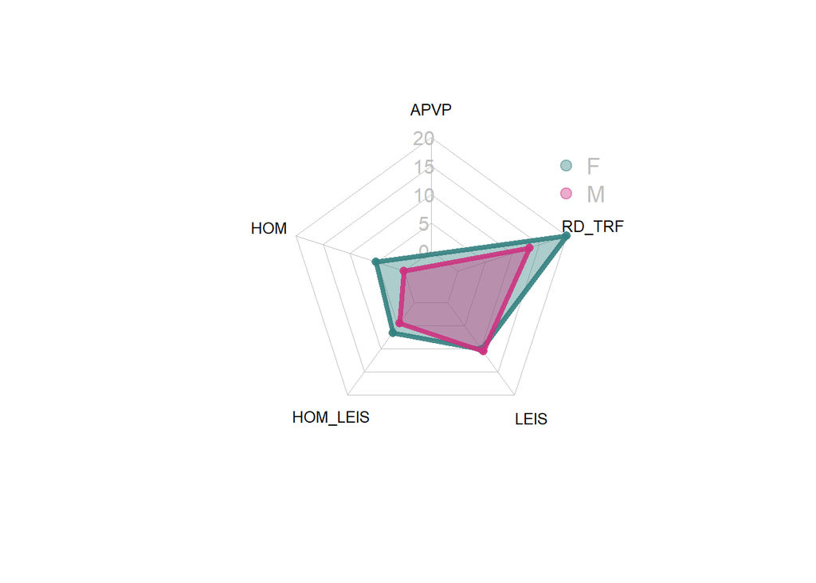

```
## [1] "ED3_4"
```

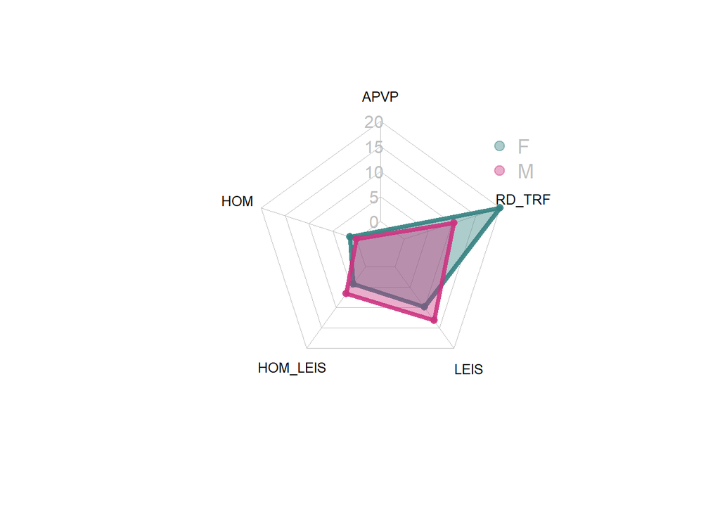

```
## [1] "ED5-8"
```

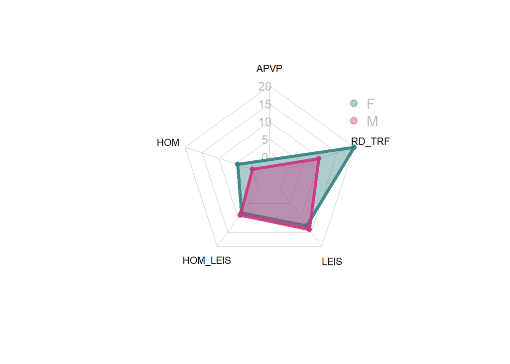

```
## [1] "TOTAL"
```

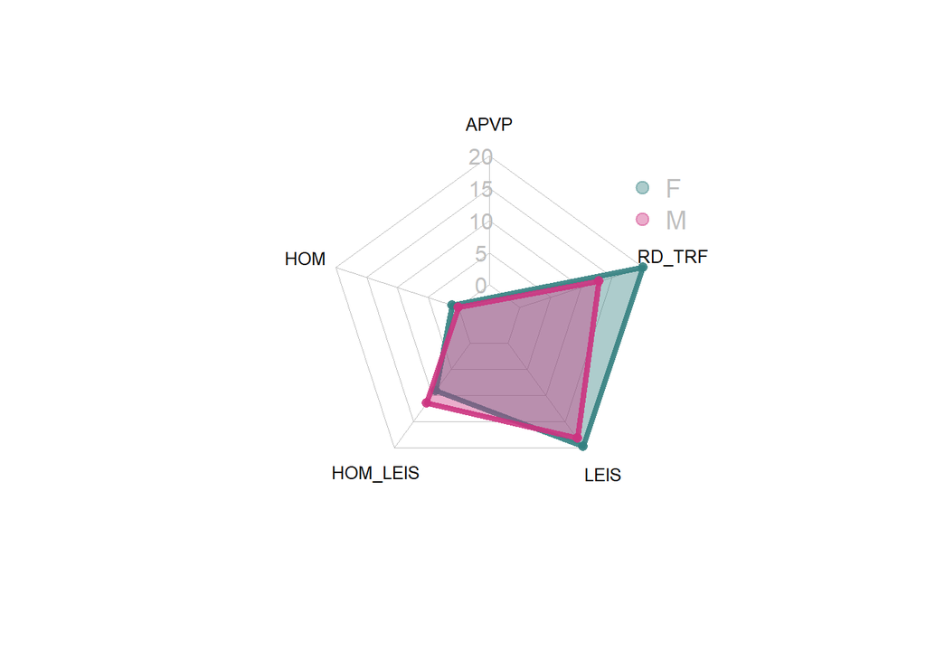

```r
#Años potenciales de vida perdidos (APVP) = Esperanza de vida – Edad promedio de los trabajadores fallecidos en accidente de [[trabajo]]
ifa <- readRDS(paste0(srcdir,"ifa.rds"))
hly <- readRDS(paste0(srcdir,"hly.rds"))
##JUGAR TB CON EL INDICADOR
hly <- hly[indic_he=='LE_0' & variable=='2014' & sex!='T' & geo=='EU27_2020']
#hly <- hly[indic_he=='LE_65' & variable=='2014' & sex!='T' & geo=='EU27_2020']
#indicator por urbanismo o nivel educativo
ifa <- ifa[Indicator=='hlth_ehis_ac1e'] #hlth_ehis_ac1u hlth_ehis_ac1e
ifa <- ifa[age == 'Y15-19' | age=='Y20-24' | age=='Y25-34' | age=='Y35-44' | age=='Y45-54' | age=='Y55-64' | age=='Y_GE65' | age=='Y_GE75']
ifa[age=='Y15-19',age2:=17]
ifa[age=='Y20-24',age2:=22]
ifa[age=='Y25-34',age2:=29.5]
ifa[age=='Y35-44',age2:=39.5]
ifa[age=='Y45-54',age2:=49.5]
ifa[age=='Y55-64',age2:=59.5]
ifa[age=='Y_GE65',age2:=65]
ifa[age=='Y_GE75',age2:=75]
ifa <- ifa[variable=='EU27_2020']

# por sexo--media ponderada de valor porcentaje de tipo de accidente y años--saco media edad accidente tipo; mantengo grado de urbanizacion
#POR INDICADOR
#ifa[!is.na(value),age.w:=weighted.mean(age2,value),by=c('sex','accident','deg_urb')]
ifa[!is.na(value),age.w:=weighted.mean(age2,value),by=c('sex','accident','isced11')]
hly_subset <- subset(hly,select=c('sex','value'))
temp <- merge(ifa,hly_subset,by='sex')
#POR INDICADOR
#temp[,APVP:=value.y-age.w,by=c('sex','accident','deg_urb')]
temp[,APVP:=value.y-age.w,by=c('sex','accident','isced11')]

#PLOTS APVP -->
library(fmsb)
#por categoria de urbanismo y nivel educativo
#for (cat in unique(temp$deg_urb)){
for (cat in unique(temp$isced11)){
  print(cat)
  #POR INDICADOR
temp2 <- temp[isced11==cat]
temp2 <- temp2[!is.na(APVP)]
temp2 <- subset(temp2,select=c('sex','accident','APVP'))
temp2 <- unique(temp2,by=c('sex','accident'))
library(reshape2)
temp2 <- dcast(temp2,sex~accident)
# To use the fmsb package, I have to add 2 lines to the dataframe: the max and min of each variable to show on the plot!
temp2 <- rbind(rep(max(temp2[,2:5]),4) , rep(min(temp2[,2:5]),5) , temp2)
temp2$sex[1:2] <- c('1','2')

colors_border=c( rgb(0.2,0.5,0.5,0.9), rgb(0.8,0.2,0.5,0.9))
colors_in=c( rgb(0.2,0.5,0.5,0.4), rgb(0.8,0.2,0.5,0.4))
setnames(temp2,"sex","APVP")
#png(paste0(outplotdir,"RadarPlot_APVP_",cat,"_0.png"))
radarchart(temp2, axistype=1 ,
            #custom polygon
            pcol=colors_border , pfcol=colors_in , plwd=4 , plty=1,
            #custom the grid
            cglcol="grey", cglty=1, axislabcol="grey", caxislabels=seq(0,20,5), cglwd=0.8,
            #custom labels
            vlcex=0.8
)
legend(x=0.8, y=1, legend = temp2[-c(1,2),]$APVP, bty = "n", pch=20 , col=colors_in , text.col = "grey", cex=1.2, pt.cex=2)
#dev.off()
}
```

## 3.2 Evolución temporal de los indicadores de esperanza de vida por países

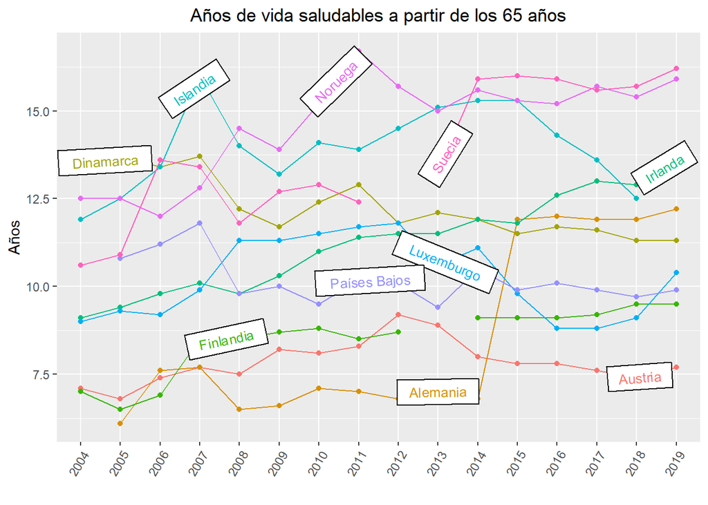

```r
hly <- readRDS(paste0(srcdir,"hly_ts.rds"))
temp <- hly[Indicator!='hlth_silc_17']
#sexo <- 'M'
# sexo total desd 2004 - 2019
sexo <- 'T'
temp <- temp[sex==sexo & unit=='YR']

# by indicador
temp <- temp[!grep('EU',geo)]
temp <- temp[!grep('EA',geo)]
paises <- fread('pib_capita.txt',header=F,encoding = 'UTF-8')
setnames(paises,'V1','geo')
paises$ID <- 1:nrow(paises)
paises$V2 <- paises$V3 <- NULL
#group by countries
temp <- merge(temp,paises,by='geo')

##solo considero del 2004 al 2019
temp <- temp[as.character(variable) >= '2004']
#for (cat in unique(temp$indic_he)){
#  print(cat)
cat <- 'HLY_65'
cat2 <- 'Años de vida saludables a partir de los 65 años'
p <- ggplot(temp[indic_he==cat & ID <=10],aes(x=as.character(variable),y=value,group=geo,color=geo))+geom_line()+geom_point()+ylab('Años')+xlab('')+ggtitle(cat2) +theme(axis.text.x = element_text(angle = 60, hjust=1))+theme(plot.title = element_text(hjust = 0.5))+  geom_dl(aes(label = pais), method =list("angled.boxes",cex=0.8))+theme(legend.position = "none")
p
```

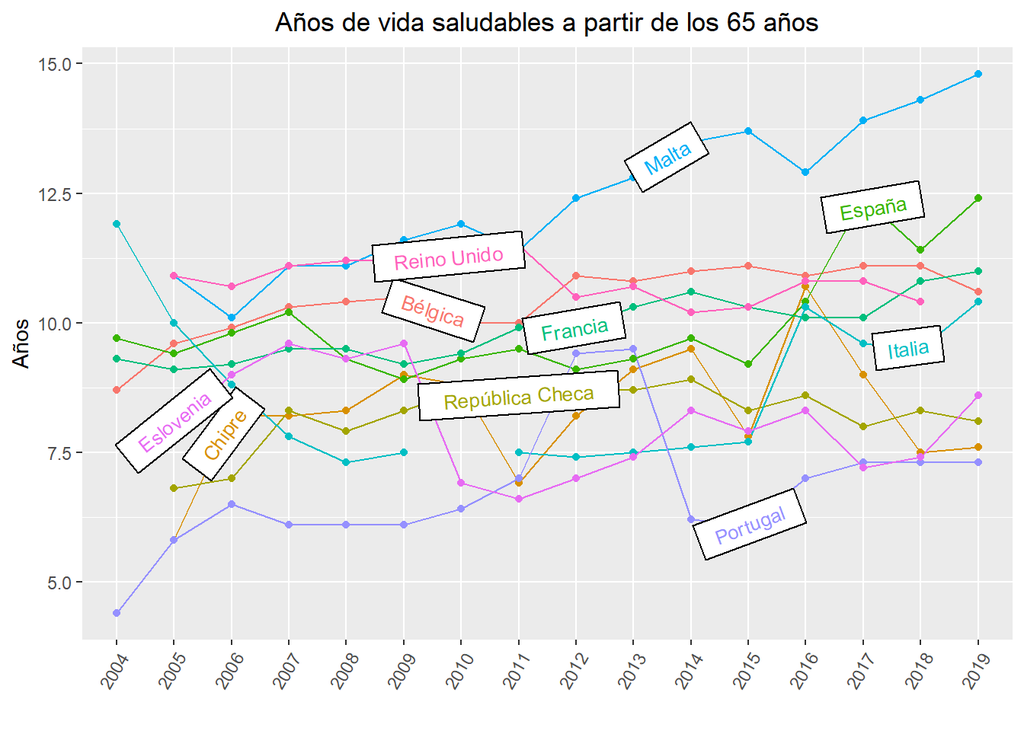

```r
ggsave(p,filename=paste0(outplotdir,"Evolucionpaises_",cat,"_0_10_",sexo,".png"),width = 10, height = 8)
p <- ggplot(temp[indic_he==cat & ID >10 & ID <= 20],aes(x=as.character(variable),y=value,group=geo,color=geo))+geom_line()+geom_point()+ylab('Años')+xlab('')+ggtitle(cat2) +theme(axis.text.x = element_text(angle = 60, hjust=1))+theme(plot.title = element_text(hjust = 0.5))+  geom_dl(aes(label = pais), method =list("angled.boxes",cex=0.8))+theme(legend.position = "none")
p
```

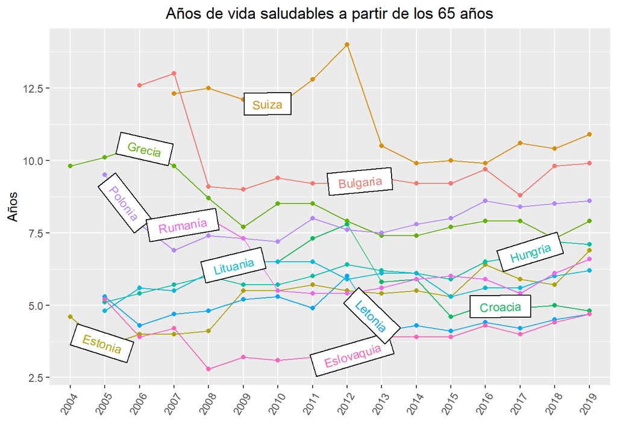

```r
ggsave(p,filename=paste0(outplotdir,"Evolucionpaises_",cat,"_10_20_",sexo,".png"),width = 10, height = 8)
p <- ggplot(temp[indic_he==cat & ID >20],aes(x=as.character(variable),y=value,group=geo,color=geo))+geom_line()+geom_point()+ylab('Años')+xlab('')+ggtitle(cat2) +theme(axis.text.x = element_text(angle = 60, hjust=1))+theme(plot.title = element_text(hjust = 0.5))+  geom_dl(aes(label = pais), method =list("angled.boxes",cex=0.8))+theme(legend.position = "none")
p
```

```r
ggsave(p,filename=paste0(outplotdir,"Evolucionpaises_",cat,"_20_31_",sexo,".png"),width = 10, height = 8)
#}
```

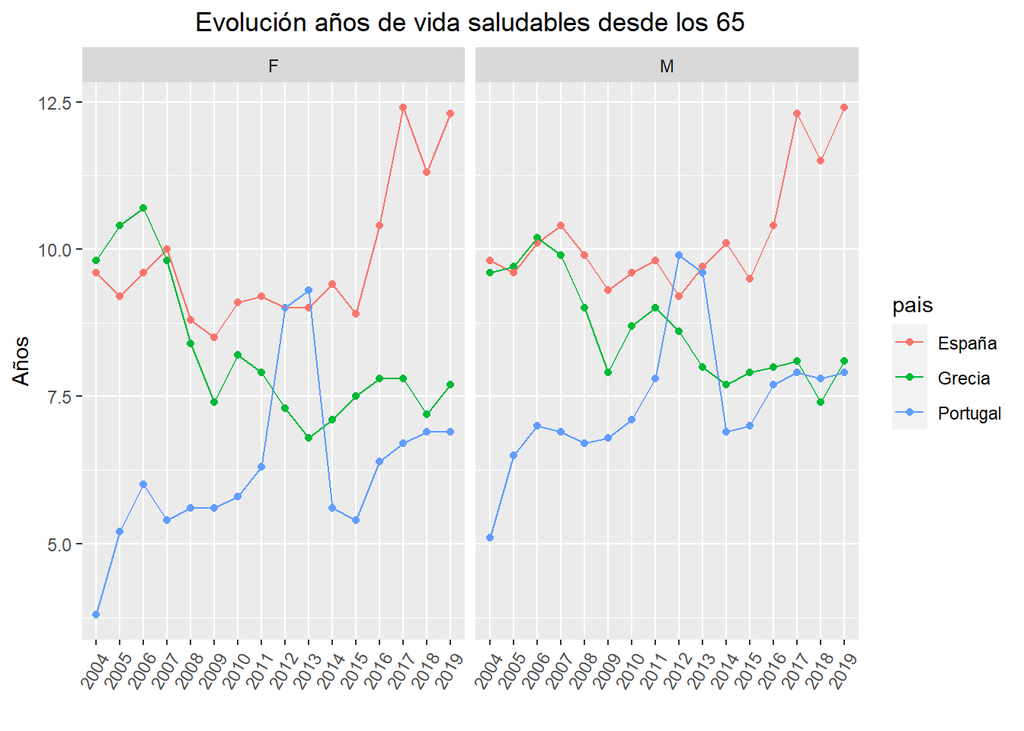

```r
temp <- hly[Indicator!='hlth_silc_17']
temp <- temp[unit=='YR']
# by indicador
temp <- temp[!grep('EU',geo)]
temp <- temp[!grep('EA',geo)]
paises <- fread('pib_capita.txt',header=F,encoding = 'UTF-8')
setnames(paises,'V1','geo')
paises$ID <- 1:nrow(paises)
paises$V2 <- paises$V3 <- NULL
#group by countries
temp <- merge(temp,paises,by='geo')

#paises afectados
temp <- temp[pais=='Grecia' | pais=='España' | pais=='Portugal']
#temp <- temp[Indicator=='hlth_hlye']

#sexo e indicador
temp2 <- temp[sex!='T' & indic_he=='HLY_65']
temp2 <- temp2[as.character(variable) >= '2004']
p <- ggplot(temp2,
       aes(x = as.character(variable),
           y = value,
           fill = pais)) + geom_point(aes(color=pais))+geom_line(aes(group=pais,color=pais)) +theme(axis.text.x = element_text(angle = 60, hjust=1))+ggtitle('Evolución años de vida saludables desde los 65')+theme(plot.title = element_text(hjust = 0.5))+facet_wrap(~sex)+xlab('')+ylab('Años')
p
```

```r
#ggsave(p,filename=paste0(outplotdir,"Evolucionpaisescrisis_HLY_65_bysexo.png"),width = 10, height = 8)
```